# Tutorial 6: Exploring Nutritional Patterns in Food Data with Principal Component Analysis

CHEE4003: Special Topics A - Artificial Intelligence in Chemical Engineering

Published

October 8, 2026

# Learning Without a Target

In previous tutorials, we focused on **supervised learning**, where a model learns the relationship between input features and a known target variable. In these problems, the goal is to predict an outcome such as product purity, temperature, or class labels from a set of measured variables. However, many real-world datasets do not include a target variable. Instead, we may simply wish to understand the structure of the data itself.

**Unsupervised learning** describes the set of techniques that discover patterns, relationships, and structure in data without being provided with a target. Rather than learning how inputs relate to an output, these methods identify similarities, differences, and hidden patterns among observations. One of the most common examples of unsupervised learning is clustering, which we explored in Week 7.

This week, we will focus on **Principal Component Analysis (PCA)**. PCA is a dimensionality reduction technique that transforms a large set of correlated variables into a smaller set of new variables called **principal components**. These components are linear combinations of the original variables and are constructed to capture as much of the variation in the data as possible. The number of principal components retained therefore becomes a **hyperparameter** that controls the balance between information retention and dimensionality reduction.

There are several reasons why PCA is widely used in machine learning and data analysis:

- **Dimensionality Reduction**: PCA can reduce the number of variables in a dataset while retaining most of the information. This improves storage efficiency and reduces computational cost, particularly for neural networks and other machine learning algorithms that struggle with high-dimensional data.
- **Visualisation**: PCA can project high-dimensional data into a lower-dimensional space, typically two or three dimensions. This makes it easier to identify patterns, clusters, and relationships that may not be apparent when examining the original variables.
- **Anomaly Detection**: PCA can be used to detect unusual observations that do not follow the main patterns in the dataset. Data points that are poorly represented by the principal components may indicate potential anomalies or outliers.

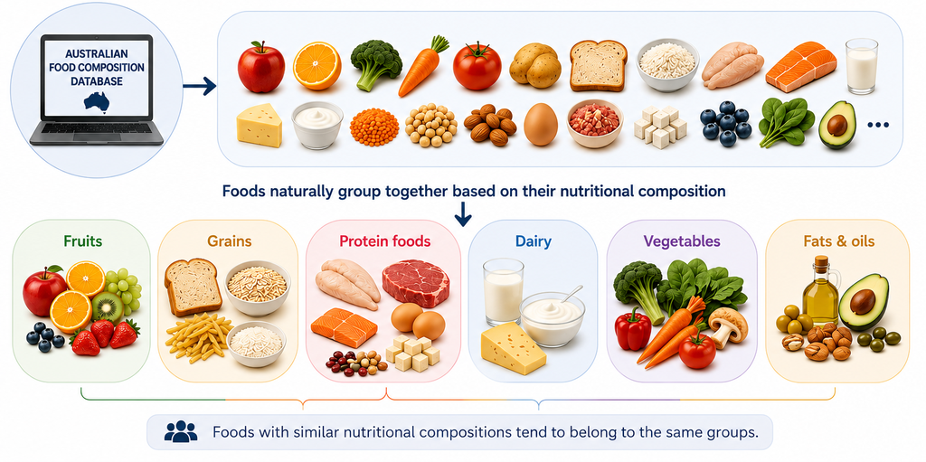

Figure 1: Example food categories represented in the dataset.

Datasets of this type are often **high-dimensional**, making them difficult to visualise and analyse. Many of the nutritional measurements are also correlated, meaning that groups of variables often capture similar information. For example, foods high in protein tend to have similar amino acid profiles, while foods rich in fat often contain related fatty acids. As a result, foods with similar nutritional compositions often form natural groups, as shown in Figure 1.

One of the main goals of **Principal Component Analysis (PCA)** is to identify the dominant patterns in such datasets by replacing hundreds of correlated variables with a much smaller number of **principal components**. These components capture the major sources of variation in the data and can be used to simplify analysis, visualise relationships between foods, and identify groups with similar nutritional characteristics.

In this tutorial, we will use PCA to investigate whether foods with similar nutritional compositions naturally group together. By projecting the data onto a small number of principal components, we will explore how well different food categories can be separated using nutritional information alone.

Download the dataset to get started:

```
ausnat_food_composition.csv
```

```
Public Food Key,Classification,Derivation,Food Name,Food Group,"Energy with dietary fibre, equated (kJ)","Energy, without dietary fibre, equated (kJ)",Moisture (water) (g),Protein (g),Nitrogen (g),"Fat, total (g)",Ash (g),Total dietary fibre (g),Alcohol (g),Fructose (g),Glucose (g),Sucrose (g),Maltose (g),Lactose (g),Galactose (g),Total sugars (g),Added sugars (g),Free sugars (g),Starch (g),Dextrin (g),Glycerol (g),Glycogen (g),Inulin (g),Erythritol (g),Maltitol (g),Mannitol (g),Xylitol (g),Maltodextrin (g),Oligosaccharides (g),Polydextrose (g),Raffinose (g),Stachyose (g),Sorbitol (g),Resistant starch (g),"Available carbohydrate, without sugar alcohols (g)","Available carbohydrate, with sugar alcohols (g)",Acetic acid (g),Citric acid (g),Fumaric acid (g),Lactic acid (g),Malic acid (g),Oxalic acid (g),Propionic acid (g),Quinic acid (g),Shikimic acid (g),Succinic acid (g),Tartaric acid (g),Aluminium (Al) (ug),Antimony (Sb) (ug),Arsenic (As) (ug),Cadmium (Cd) (ug),Calcium (Ca) (mg),Chromium (Cr) (ug),Chloride (Cl) (mg),Cobalt (Co) (ug),Copper (Cu) (mg),Fluoride (F) (ug),Iodine (I) (ug),Iron (Fe) (mg),Lead (Pb) (ug),Magnesium (Mg) (mg),Manganese (Mn) (mg),Mercury (Hg) (ug),Molybdenum (Mo) (ug),Nickel (Ni) (ug),Phosphorus (P) (mg),Potassium (K) (mg),Selenium (Se) (ug),Sodium (Na) (mg),Sulphur (S) (mg),Tin (Sn) (ug),Zinc (Zn) (mg),Retinol (preformed vitamin A) (ug),Alpha-carotene (ug),Beta-carotene (ug),Cryptoxanthin (ug),Beta-carotene equivalents (provitamin A) (ug),Vitamin A retinol equivalents (ug),Lutein (ug),Lycopene (ug),Xanthophyl (ug),Thiamin (B1) (mg),Riboflavin (B2) (mg),Niacin (B3) (mg),Niacin derived from tryptophan (mg),Niacin derived equivalents (mg),Pantothenic acid (B5) (mg),Pyridoxine (B6) (mg),Biotin (B7) (ug),Cobalamin (B12) (ug),"Folate, natural (ug)",Folic acid (ug),Total folates (ug),Dietary folate equivalents (ug),Vitamin C (mg),Cholecalciferol (D3) (ug),Ergocalciferol (D2) (ug),25-hydroxy cholecalciferol (25-OH D3) (ug),25-hydroxy ergocalciferol (25-OH D2) (ug),Vitamin D3 equivalents (ug),Alpha tocopherol (mg),Alpha tocotrienol (mg),Beta tocopherol (mg),Beta tocotrienol (mg),Delta tocopherol (mg),Delta tocotrienol (mg),Gamma tocopherol (mg),Gamma tocotrienol (mg),Vitamin E (mg),C4 (%T),C6 (%T),C8 (%T),C10 (%T),C11 (%T),C12 (%T),C13 (%T),C14 (%T),C15 (%T),C16 (%T),C17 (%T),C18 (%T),C19 (%T),C20 (%T),C21 (%T),C22 (%T),C23 (%T),C24 (%T),"Total saturated fatty acids, equated (%T)",C12:1 (%T),C14:1 (%T),C15:1 (%T),C16:1 (%T),C17:1 (%T),C18:1 (%T),C18:1w7 (%T),C20:1 (%T),C20:1w11 (%T),C22:1 (%T),C22:1w11 (%T),C24:1 (%T),"Total monounsaturated fatty acids, equated (%T)",C12:2 (%T),C16:2w4 (%T),C16:3 (%T),C18:2w6 (%T),C18:3w3 (%T),C18:3w4 (%T),C18:3w6 (%T),C18:4w1 (%T),C18:4w3 (%T),C20:2 (%T),C20:2w6 (%T),C20:4 (%T),C20:3w3 (%T),C20:3w6 (%T),C20:4w3 (%T),C20:4w6 (%T),C20:5w3 (%T),C21:5w3 (%T),C22:2 (%T),C22:2w6 (%T),C22:4w6 (%T),C22:5w3 (%T),C22:5w6 (%T),C22:6w3 (%T),"Total polyunsaturated fatty acids, equated (%T)","Total long chain omega 3 fatty acids, equated (%T)",Total undifferentiated fatty acids (%T),"Total trans fatty acids, imputed (%T)",C4 (g),C6 (g),C8 (g),C10 (g),C11 (g),C12 (g),C13 (g),C14 (g),C15 (g),C16 (g),C17 (g),C18 (g),C19 (g),C20 (g),C21 (g),C22 (g),C23 (g),C24 (g),"Total saturated fatty acids, equated (g)",C12:1 (g),C14:1 (g),C15:1 (g),C16:1 (g),C17:1 (g),C18:1 (g),C18:1w7 (g),C20:1 (g),C20:1w11 (mg),C22:1 (g),C22:1w11 (mg),C24:1 (g),"Total monounsaturated fatty acids, equated (g)",C12:2 (g),C16:2w4 (mg),C16:3 (g),C18:2w6 (g),C18:3w3 (g),C18:3w4 (g),C18:3w6 (mg),C18:4w1 (g),C18:4w3 (mg),C20:2 (mg),C20:2w6 (mg),C20:3 (mg),C20:3w3 (mg),C20:3w6 (mg),C20:4 (g),C20:4w3 (mg),C20:4w6 (mg),C20:5w3 (mg),C21:5w3 (g),C22:5w3 (mg),C22:4w6 (mg),C22:2 (g),C22:2w6 (mg),C22:5w6 (g),C22:6w3 (mg),"Total polyunsaturated fatty acids, equated (g)","Total long chain omega 3 fatty acids, equated (mg)","Total undifferentiated fatty acids, mass basis (mg)","Total trans fatty acids, imputed (mg)",Caffeine (mg),Cholesterol (mg),Alanine (mg/gN),Arginine (mg/gN),Aspartic acid (mg/gN),Cystine plus cysteine (mg/gN),Glutamic acid (mg/gN),Glycine (mg/gN),Histidine (mg/gN),Isoleucine (mg/gN),Leucine (mg/gN),Lysine (mg/gN),Methionine (mg/gN),Phenylalanine (mg/gN),Proline (mg/gN),Serine (mg/gN),Threonine (mg/gN),Tyrosine (mg/gN),Tryptophan (mg/gN),Valine (mg/gN),Alanine (mg),Arginine (mg),Aspartic acid (mg),Cystine plus cysteine (mg),Glutamic acid (mg),Glycine (mg),Histidine (mg),Isoleucine (mg),Leucine (mg),Lysine (mg),Methionine (mg),Phenylalanine (mg),Proline (mg),Serine (mg),Threonine (mg),Tyrosine (mg),Tryptophan (mg),Valine (mg)
F002258,31302,Borrowed,"Cardamom seed, dried, ground",Other,1236,1012,8.3,10.8,1.72,6.7,5.8,28.0,0.0,,,,,,,4.4,0.0,0.0,30.0,,,,,,,,,,,,,,,,34.4,34.4,,,,,,,,,,,,,,,,383,,,,,,0.0,13.97,,229,,,,,178,1119,11.7,18,,,7.47,0,,22,,22,4,,,,0.198,0.182,1.1,2.64,3.74,,0.23,,0.0,3,0,3,3,21,0.0,0.0,0.0,0.0,0.0,2.8,,,,,,,,2.85,,,,,,,,,,,,,,,,,,,34.34,,,,,,,,,,,,,43.94,,,,15.6,6.1,,,,,,,,,,,,0.0,,,,,0.0,,0.0,21.72,0.0,,0.0,,,,,,,,,,,,,,,,,,,2.2,,,,,,,,,,,,,2.81,,,,1.0,0.39,,,,,,,,,,,,,0.0,,0.0,,,,,0.0,1.39,0.0,,0.0,0,0,,,,,,,,,,,,,,,,,90.0,,,,,,,,,,,,,,,,,,155,
F002963,31302,Borrowed,"Cinnamon, dried, ground",Other,1004,579,10.6,4.0,0.64,1.2,3.6,53.1,0.0,,,,,,,2.2,0.0,0.0,25.3,,,,,,,,,,,,,,,,27.5,27.5,,,,,,,,,,,,,,,,1002,,,,,,0.1,8.32,,60,,,,,64,431,3.1,10,,,1.83,0,,112,,112,19,,,,0.022,0.041,1.33,0.83,2.16,,0.16,,0.0,6,0,6,6,4,0.0,0.0,0.0,0.0,0.0,2.3,,,,,,,,2.32,,,,,,,,,,,,,,,,,,,52.35,,,,,,,,,,,,,37.33,,,,6.7,1.7,,,,,,,,,,,,0.0,,,,,0.0,,0.0,10.32,0.0,,0.0,,,,,,,,,,,,,,,,,,,0.62,,,,,,,,,,,,,0.44,,,,0.08,0.02,,,,,,,,,,,,,0.0,,0.0,,,,,0.0,0.12,0.0,,0.0,0,0,,,,,,,,,,,,,,,,,77.0,,,,,,,,,,,,,,,,,,49,
F002893,31302,Borrowed,"Chilli (chili), dried, ground",Other,1224,950,10.8,12.3,2.0,14.3,8.5,34.2,0.0,,,,,,,7.2,0.0,0.0,5.7,,,,,,,,,,,,,,,,12.9,12.9,,,,,,,,,,,,,,,,278,,,,,,2.3,14.3,,170,,,,,303,1920,8.6,68,,,2.7,0,2090.0,15000,,16045,2674,,,,0.35,0.79,10.0,1.09,11.09,,1.9,,0.0,100,0,100,100,64,0.0,0.0,0.0,0.0,0.0,1.0,,,,,,,,1.0,,,,,,,,,,,,,,,,,,,18.0,,,,,,,,,,,,,23.47,,,,54.6,3.9,,,,,,,,,,,,0.0,,,,,0.0,,0.0,58.53,0.0,,0.0,,,,,,,,,,,,,,,,,,,2.06,,,,,,,,,,,,,2.68,,,,6.25,0.45,,,,,,,,,,,,,0.0,,0.0,,,,,0.0,6.7,0.0,,0.0,0,0,,,,,,,,,,,,,,,,,32.0,,,,,,,,,,,,,,,,,,64,
F002970,31302,Borrowed,"Cloves, dried, ground",Other,1389,1118,9.9,6.0,0.96,13.0,5.6,33.9,0.0,,,,,,,2.4,0.0,0.0,29.2,,,,,,,,,,,,,,,,31.6,31.6,,,,,,,,,,,,,,,,632,,,,,,50.7,11.83,,259,,,,,104,1020,7.2,277,,,2.32,0,,45,,45,8,,,,0.216,0.22,1.56,0.51,2.07,,0.39,,0.0,25,0,25,25,0,0.0,0.0,0.0,0.0,0.0,8.8,,,,,,,,8.82,,,,,,,,,,,,,,,,,,,44.15,,,,,,,,,,,,,15.56,,,,29.7,6.5,,,,,,,,,,,,0.1,,,,,2.0,,0.0,40.45,2.145,,0.0,,,,,,,,,,,,,,,,,,,5.49,,,,,,,,,,,,,1.93,,,,3.69,0.81,,,,,,,,,,,,,11.06,,255.52,,,,,0.0,5.03,266.581,,0.0,0,0,,,,,,,,,,,,,,,,,31.0,,,,,,,,,,,,,,,,,,30,
... (1585 more lines)
```

In this dataset, the first few columns contain information used to identify and categorise each food, while the remaining columns contain nutritional measurements.

| Column | Description |
| --- | --- |
| Public Food Key | Unique identifier assigned to each food item in the database |
| Classification | Food classification code used within the database |
| Derivation | Source of the nutritional data (analysed, borrowed, imputed, or recipe-based) |
| Food Name | Name of the food item |
| Food Group | Broad food category derived from the classification code |
| *268 additional columns* | Nutritional measurements including energy, macronutrients, minerals, vitamins, individual fatty acids, and amino acids |

Some of the nutritional variables contain missing values. To simplify the analysis, columns with missing values will be removed for the purposes of this tutorial.

The `Food Group` column provides an expert classification of the foods based on their nutritional characteristics. Although PCA is an unsupervised learning technique and **does not use these labels** during training, we will use them later to evaluate how well the principal components separate different types of foods.

Before anything else, we need to have the correct libraries imported. Copy the following code into your script to import the necessary libraries:

```
import_libraries.py
```

```python
import numpy as np
import pandas as pd
import matplotlib.pyplot as plt
from sklearn.preprocessing import StandardScaler
from sklearn.model_selection import train_test_split, KFold
```

**NoteWhat PCA does**

PCA looks for the direction in the feature space along which the data varies the most, and calls it the **first principal component**. It then looks for the direction of greatest remaining variation that is orthogonal (perpendicular) to the first, and calls that the second, and so on until it runs out of dimensions (the number of features).

The result is a new set of axes describing the same data. For a dataset with $p$ features, PCA produces $p$ principal components. However, the variation in the data is often concentrated in the first few components, while later components contribute relatively little information. This allows us to retain only the most important components while still preserving most of the variation in the original dataset.

Two important terms that we will use throughout this tutorial are:

- **Loadings**: How each original feature contributes to a component. There is one loading value for every feature in every component, and together they tell us what the component *means*. Essentially, the loadings describe the linear combination of the original features that defines a component.
- **Scores**: Where each sample sits along each component. These are the new coordinates of the samples after they have been projected onto the principal component axes.

### Task 1 : Load the dataset

Write a function `load_food_data` that reads the dataset and returns three objects: the feature matrix `X_raw`, the food names, and the food group labels. To create `X_raw`, first remove the five identifying columns listed below, then retain only the nutritional measurement columns that contain no missing values.

The five identifying columns are:

```python
LABELS = ["Public Food Key", "Classification",
          "Derivation", "Food Name", "Food Group"]
```

**TipDropping columns instead of rows**

`DataFrame.dropna()` removes rows containing missing values by default. Passing `axis=1` makes it remove *columns* instead, so `data.dropna(axis=1)` keeps only the columns with no missing values.

That is exactly what we want here: a food missing one nutritional measurement can still be used in the analysis, but a variable that has missing values across many foods cannot be included when calculating the covariance matrix required for PCA.

For more information, see the [Pandas `DataFrame.dropna()` documentation](https://pandas.pydata.org/docs/reference/api/pandas.DataFrame.dropna.html).

```
load_food_data.py
```

```python
def load_food_data(file_path):
    """
    Load the food composition data and return the features, names and groups.

    Parameters
    ----------
    file_path : str
        The path to the CSV file containing the dataset.

    Returns
    -------
    X_raw : pd.DataFrame
        Every measured column that is complete for all foods.
    names : pd.Series
        The name of each food.
    groups : pd.Series
        The major food group of each food.
    """
```

When you run this function, it should yield the following output:

X_raw, names, groups = load_food_data('data/ausnat_food_composition.csv')

Foods: 1588

Measured columns: 268

Dropped for gaps: 208

Columns kept: 60

To inspect the cleaned dataset, display the first four foods and the first five nutritional variables. Here, `.round(1)` rounds the displayed values to one decimal place, making the output easier to read.

X_raw.iloc[:4, :5].round(1)

Energy with dietary fibre, equated (kJ) \

0 1236

1 1004

2 1224

3 1389

Energy, without dietary fibre, equated (kJ) Moisture (water) (g) \

0 1012 8.3

1 579 10.6

2 950 10.8

3 1118 9.9

Protein (g) Nitrogen (g)

0 10.8 1.7

1 4.0 0.6

2 12.3 2.0

3 6.0 1.0

**Callout-answer**Answer**

```
load_food_data.py
```

```python
LABELS = ["Public Food Key", "Classification", "Derivation", "Food Name", "Food Group"]

def load_food_data(file_path):
    """
    Load the food composition data and return the features, names and groups.

    Parameters
    ----------
    file_path : str
        The path to the CSV file containing the dataset.

    Returns
    -------
    X_raw : pd.DataFrame
        Every measured column that is complete for all foods.
    names : pd.Series
        The name of each food.
    groups : pd.Series
        The major food group of each food.
    """
    data = pd.read_csv(file_path)

    measurements = data.drop(columns=LABELS)
    X_raw = measurements.dropna(axis=1)

    names = data["Food Name"]
    groups = data["Food Group"]

    print(f"Foods:                {X_raw.shape[0]}")
    print(f"Measured columns:     {measurements.shape[1]}")
    print(f"Dropped for gaps:     {measurements.shape[1] - X_raw.shape[1]}")
    print(f"Columns kept:         {X_raw.shape[1]}")
    return X_raw, names, groups

X_raw, names, groups = load_food_data('data/ausnat_food_composition.csv')
print(X_raw.iloc[:4, :5].round(1))
```

Output

```
Foods:                1588
Measured columns:     268
Dropped for gaps:     208
Columns kept:         60
   Energy with dietary fibre, equated (kJ)  \
0                                     1236
1                                     1004
2                                     1224
3                                     1389

   Energy, without dietary fibre, equated (kJ)  Moisture (water) (g)  \
0                                         1012                   8.3
1                                          579                  10.6
2                                          950                  10.8
3                                         1118                   9.9

   Protein (g)  Nitrogen (g)
0         10.8           1.7
1          4.0           0.6
2         12.3           2.0
3          6.0           1.0
```

### Task: 2 Put the columns on a comparable footing

Many nutritional variables are extremely unevenly distributed. For example, most foods contain very little sodium, while table salt contains almost 40,000 mg per 100 g. Similarly, selenium is present only in trace amounts in most foods, while a small number of foods contain much larger concentrations.

As a result, many variables are dominated by a handful of extreme values. When plotted, most foods are compressed into a narrow region near zero, while a few observations stretch the scale dramatically. This makes it difficult to visualise patterns and can cause those extreme values to have a disproportionate influence on the analysis.

A common solution is to apply a **logarithmic transformation**, which compresses large values much more than small values. This reduces skewness, spreads observations more evenly across the scale, and often makes the underlying structure of the data easier to see.

**NoteInterpreting skewness**

**Skewness** measures how asymmetric a distribution is.

**Direction of skewness:**

- **Skewness ≈ 0**: approximately symmetric distribution.
- **Skewness > 0**: positively (right) skewed. The distribution contains a small number of unusually large values.
- **Skewness < 0**: negatively (left) skewed. The distribution contains a small number of unusually small values.

**Magnitude of skewness (rough guide):**

- **|Skewness| > 1**: noticeably skewed.
- **|Skewness| > 2**: strongly skewed.
- **|Skewness| > 10**: extremely skewed, indicating the presence of a few observations that are much larger or smaller than the majority of the data.

These thresholds are only rough guidelines, and their interpretation depends on the application and sample size.

Write a function `log_transform` that applies a logarithmic transformation to the data using `np.log1p()`. Use `DataFrame.skew()` to calculate the skewness of each variable before and after the transformation. The function should display the eight most skewed variables and report how many columns have a skewness greater than 10 before and after the transformation.

**TipWhy `log1p` and not `log`**

Many entries in this table are exactly zero, and $\log 0$ is undefined. `np.log1p(x)` computes $\log(1 + x)$, which maps zero to zero and is accurate for small $x$, so the whole table can be transformed in one call. `DataFrame.skew()` returns the skewness of every column, where a value near zero means a symmetric distribution and a large positive value means a long right tail. See [np.log1p](https://numpy.org/doc/stable/reference/generated/numpy.log1p.html) and [DataFrame.skew](https://pandas.pydata.org/docs/reference/api/pandas.DataFrame.skew.html).

```
log_transform.py
```

```python
def log_transform(X_raw):
    """
    Take logarithms of every column and show what that does to the distributions.

    Parameters
    ----------
    X_raw : pd.DataFrame
        The measured feature table.

    Returns
    -------
    X : pd.DataFrame
        The log-transformed table.
    """
```

When you run this function, it should yield the following output:

X = log_transform(X_raw)

Raw skew Log skew

Caffeine (mg) 38.1 6.5

Selenium (Se) (ug) 34.7 0.2

Potassium (K) (mg) 31.6 -1.9

Iodine (I) (ug) 30.2 1.1

Retinol (preformed vitamin A) (ug) 30.1 1.6

Ergocalciferol (D2) (ug) 29.0 12.1

Vitamin A retinol equivalents (ug) 28.2 0.8

Thiamin (B1) (mg) 26.6 5.2

Columns with skewness above 10: raw 22 log 1

Which nutrient remains the most skewed after the logarithmic transformation? What does this suggest about the distribution of that nutrient across foods?

**Callout-answer**Answer**

```
log_transform.py
```

```python
def log_transform(X_raw):
    """
    Take logarithms of every column and show what that does to the distributions.

    Parameters
    ----------
    X_raw : pd.DataFrame
        The measured feature table.

    Returns
    -------
    X : pd.DataFrame
        The log-transformed table.
    """
    X = np.log1p(X_raw)

    skew = pd.DataFrame({"Raw skew": X_raw.skew(), "Log skew": X.skew()})
    print(skew.sort_values("Raw skew", ascending=False).head(8).round(1))
    print(f"\nColumns with skewness above 10:   raw {(X_raw.skew() > 10).sum()}   log {(X.skew() > 10).sum()}")
    return X

X = log_transform(X_raw)
```

Output

```
                                    Raw skew  Log skew
Caffeine (mg)                           38.1       6.5
Selenium (Se) (ug)                      34.7       0.2
Potassium (K) (mg)                      31.6      -1.9
Iodine (I) (ug)                         30.2       1.1
Retinol (preformed vitamin A) (ug)      30.1       1.6
Ergocalciferol (D2) (ug)                29.0      12.1
Vitamin A retinol equivalents (ug)      28.2       0.8
Thiamin (B1) (mg)                       26.6       5.2

Columns with skewness above 10:   raw 22   log 1
```

Ergocalciferol (D2) remains the most skewed nutrient after the logarithmic transformation, with a skewness of **12.1**. This suggests that most foods contain little or no Ergocalciferol, while a small number of foods contain much larger amounts. As a result, the distribution remains highly right-skewed even after the transformation.

### Task: 3 Look for redundancy

One of the key motivations for PCA is that many variables often contain overlapping information. When this happens, the data effectively occupies fewer dimensions than the number of columns suggests.

As in **Tutorial 1**, we can use a **correlation matrix** to identify relationships between variables. Highly correlated pairs of variables may be measuring similar underlying properties, indicating potential redundancy in the dataset.

Write a function `plot_correlation_matrix` that computes the correlation matrix and displays it as a heatmap. No need to include the feature labels in this figure, as there are too many variables for them to be displayed clearly.

```
plot_correlation_matrix.py
```

```python
def plot_correlation_matrix(X, n_pairs=8):
    """
    Draw the correlation matrix as a heatmap and list the strongest pairs.

    Parameters
    ----------
    X : pd.DataFrame
        The feature table.
    n_pairs : int, optional
        How many of the strongest pairs to print (default is 8).

    Returns
    -------
    corr : pd.DataFrame
        The correlation matrix.
    """
```

corr = plot_correlation_matrix(X)

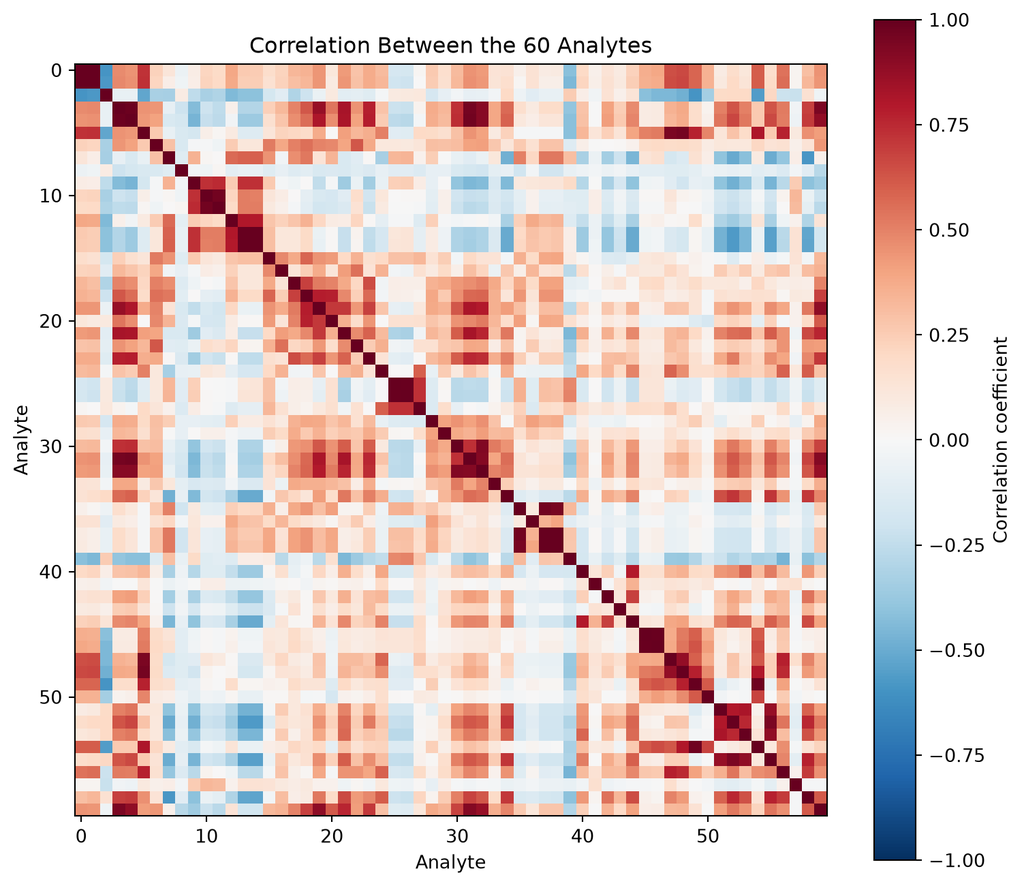

The heatmap contains several large red blocks along the diagonal, indicating groups of analytes that tend to increase and decrease together. These strong correlations suggest that many variables contain overlapping information and are therefore partially redundant.

Because PCA is designed to identify and combine correlated variables into a smaller set of components, the presence of these correlation patterns suggests that PCA should be highly effective at reducing the dimensionality of this dataset while retaining most of the underlying information.

**Callout-answer**Answer**

```
plot_correlation_matrix.py
```

```python
def plot_correlation_matrix(X, n_pairs=8):
    """
    Draw the correlation matrix as a heatmap and list the strongest pairs.

    Parameters
    ----------
    X : pd.DataFrame
        The feature table.
    n_pairs : int, optional
        How many of the strongest pairs to print (default is 8).

    Returns
    -------
    corr : pd.DataFrame
        The correlation matrix.
    """
    corr = X.corr()

    plt.figure(figsize=(8, 7))
    plt.imshow(corr, cmap="RdBu_r", vmin=-1, vmax=1)
    plt.colorbar(label="Correlation coefficient")
    plt.title(f"Correlation Between the {X.shape[1]} Analytes")
    plt.xlabel("Analyte")
    plt.ylabel("Analyte")
    plt.tight_layout()
    plt.show()
    return corr

corr = plot_correlation_matrix(X)
```

Output

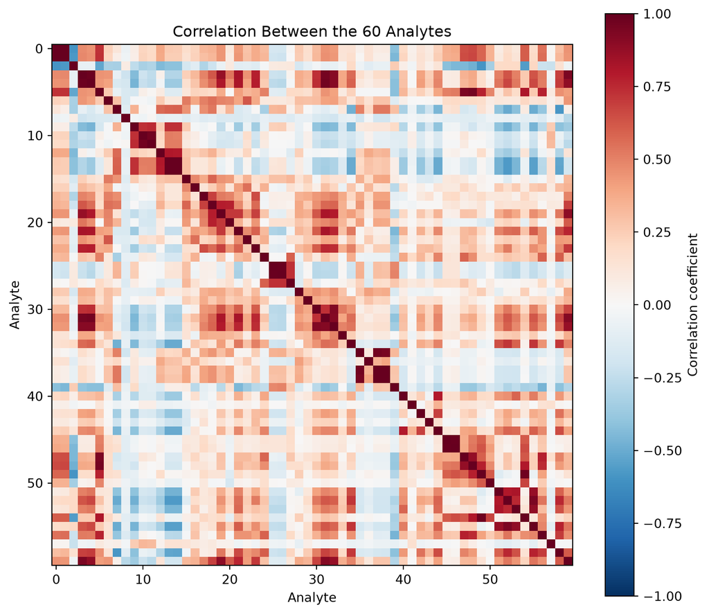

## Part B: Finding the components by hand

In previous tutorials, we relied on `scikit-learn` estimators to fit machine learning models. PCA, however, is simple enough that we can implement the core algorithm ourselves. Doing so helps us understand exactly where the principal components, loadings, and scores come from.

**NotePCA is an eigenvalue problem**

The goal of PCA is to find the directions in the feature space along which the data varies the most. These directions become the **principal components**.

We begin with the standardised data matrix $\mathbf{Z}$, which has $n$ rows (samples) and $p$ columns (features). Each feature has zero mean and unit standard deviation. From this matrix, we calculate the covariance matrix

$$\mathbf{C} = \frac{1}{n-1}\mathbf{Z}^{\top}\mathbf{Z},$$

a symmetric $p \times p$ matrix describing how the features vary together. Since the data have been standardised, $\mathbf{C}$ is equivalent to the correlation matrix visualised in the previous task.

PCA then searches for the direction $\mathbf{v}$ along which the variance of the data is largest. This variance is given by $\mathbf{v}^{\top}\mathbf{C}\mathbf{v}$. Maximising this quantity, subject to $\lVert\mathbf{v}\rVert = 1$, leads to the eigenvalue equation

$$\mathbf{C}\mathbf{v} = \lambda\mathbf{v},$$

The resulting **eigenvectors** define the principal component directions, while the corresponding **eigenvalues** measure how much variance each component explains. Sorting the eigenvectors by decreasing eigenvalue therefore orders the components from most important to least important.

If the eigenvectors are collected into a matrix $\mathbf{V}$, then:

- **Loadings** are the columns of $\mathbf{V}$.
- **Scores** are obtained by projecting the data onto these directions:

$$\mathbf{T} = \mathbf{Z}\mathbf{V}.$$

That is the entire PCA algorithm: standardise the data, compute the covariance matrix, find its eigenvectors, sort them by eigenvalue, and project the data onto the resulting components.

Notice that the eigenvalue decomposition is performed on a matrix whose size depends only on the number of **features**, not the number of samples. In our case, this means decomposing a $60 \times 60$ matrix regardless of whether the dataset contains hundreds or thousands of foods.

### Task 4 : Standardise the data and find the components

Write a function `fit_pca` that standardises the feature table with a `StandardScaler`, builds the covariance matrix of the standardised data, and returns the eigenvectors and eigenvalues sorted from largest to smallest. Return the fitted scaler as well, since you will need it to put any new data on the same scale later.

Give the function a `standardise` argument that defaults to `True`. Passing `with_std=False` to the scaler centres each column without dividing by its standard deviation, which gives us a way to switch the scaling off in a later task and see what happens.

**TipThe scaler and the linear algebra**

`StandardScaler().fit(X)` learns the mean and standard deviation of every column, and `scaler.transform(X)` applies them. Holding on to the fitted scaler is what lets you put new data on the same scale later, and its `inverse_transform` reverses the operation, which Part D depends on.

`np.cov(Z, rowvar=False)` then builds the covariance matrix, where `rowvar=False` says that the columns are the variables. `np.linalg.eigh(C)` returns the eigenvalues and eigenvectors of a symmetric matrix, with column `i` of the eigenvector array belonging to eigenvalue `i`. Use `eigh` rather than the general-purpose `eig`: it exploits the symmetry of a covariance matrix, so it is faster and it guarantees real results.

`eigh` returns its eigenvalues in *ascending* order, so you must reverse them. `np.argsort(eigenvalues)[::-1]` gives the indices that put them in descending order, and the same index array reorders the eigenvector columns.

**Note**

An eigenvector and its negative describe the same axis. Fix the sign of the eigenvector by looking at its largest entry and flipping the vector if that entry is negative. This is standard PCA practice that makes the loadings easier to read, because it avoids a random mix of positive and negative signs in the output.

```
fit_pca.py
```

```python
def fit_pca(X, standardise=True):
    """
    Standardise the features and find the principal components of their covariance matrix.

    Parameters
    ----------
    X : pd.DataFrame
        The feature table.
    standardise : bool, optional
        Whether to divide each column by its standard deviation (default is True).

    Returns
    -------
    scaler : StandardScaler
        The scaler fitted to X.
    loadings : np.ndarray
        The eigenvectors, one component per column, in decreasing order of variance.
    variance : np.ndarray
        The variance carried by each component, in decreasing order.
    """
```

When you run this, it should yield the following output:

scaler, loadings, variance = fit_pca(X)

print(f"Loadings: {loadings.shape}")

Loadings: (60, 60)

print(f"Variance: {variance.shape}")

Variance: (60,)

variance[:6].round(2)

array([15.84, 8.47, 6.55, 3.88, 3.39, 1.96])

The sixty standardised columns carry one unit of variance each, so there are sixty units in the table altogether.

**Callout-answer**Answer**

```
fit_pca.py
```

```python
def fit_pca(X, standardise=True):
    """
    Standardise the features and find the principal components of their covariance matrix.

    Parameters
    ----------
    X : pd.DataFrame
        The feature table.
    standardise : bool, optional
        Whether to divide each column by its standard deviation (default is True).

    Returns
    -------
    scaler : StandardScaler
        The scaler fitted to X.
    loadings : np.ndarray
        The eigenvectors, one component per column, in decreasing order of variance.
    variance : np.ndarray
        The variance carried by each component, in decreasing order.
    """
    scaler = StandardScaler(with_std=standardise).fit(X)
    Z = scaler.transform(X)

    variance, loadings = np.linalg.eigh(np.cov(Z, rowvar=False))

    # eigh returns the eigenvalues smallest first, so put the largest first
    order = np.argsort(variance)[::-1]
    variance, loadings = variance[order], loadings[:, order]

    # An eigenvector and its negative are the same axis, so pin the sign
    for i in range(loadings.shape[1]):
        if loadings[np.abs(loadings[:, i]).argmax(), i] < 0:
            loadings[:, i] = -loadings[:, i]

    return scaler, loadings, variance

scaler, loadings, variance = fit_pca(X)
print(f"Loadings: {loadings.shape}")
print(f"Variance: {variance.shape}")
print(variance[:6].round(2))
```

Output

```
Loadings: (60, 60)
Variance: (60,)
[15.84  8.47  6.55  3.88  3.39  1.96]
```

### Task 5 : Project the foods onto the components

Write a function `pca_scores` that does exactly to get the coordinates of each food on the new axes, standardise the table with the fitted scaler and matrix multiply by the loading matrix.

```
pca_scores.py
```

```python
def pca_scores(X, scaler, loadings):
    """
    Project a feature table onto a set of principal components.

    Parameters
    ----------
    X : pd.DataFrame
        The feature table to project.
    scaler : StandardScaler
        The fitted scaler from fit_pca.
    loadings : np.ndarray
        The loading matrix from fit_pca.

    Returns
    -------
    scores : np.ndarray
        The component scores, one row per sample and one column per component.
    """
```

**TipMatrix multiplication in NumPy**

The `@` operator performs matrix multiplication, so `Z @ loadings` multiplies an $n \times p$ array by a $p \times p$ array to give an $n \times p$ array of scores. Taking the scaler as an argument, instead of fitting a fresh one inside the function, is what lets you project new data onto components that were fitted on old data.

When you run this function, it should yield the following output:

scores = pca_scores(X, scaler, loadings)

print(f"Original table: {X.shape}")

Original table: (1588, 60)

print(f"Scores: {scores.shape}")

Scores: (1588, 60)

scores[:3, :4].round(2)

array([[ 1.02, 5.18, -0.78, 0.55],

[-1.65, 3.96, -1.32, 1.11],

[ 2.17, 7.34, -2.6 , 4.93]])

**Callout-answer**Answer**

```
pca_scores.py
```

```python
def pca_scores(X, scaler, loadings):
    """
    Project a feature table onto a set of principal components.

    Parameters
    ----------
    X : pd.DataFrame
        The feature table to project.
    scaler : StandardScaler
        The fitted scaler from fit_pca.
    loadings : np.ndarray
        The loading matrix from fit_pca.

    Returns
    -------
    scores : np.ndarray
        The component scores, one row per sample and one column per component.
    """
    return scaler.transform(X) @ loadings

scores = pca_scores(X, scaler, loadings)
print(f"Original table: {X.shape}")
print(f"Scores:         {scores.shape}")
print(scores[:3, :4].round(2))
```

Output

```
Original table: (1588, 60)
Scores:         (1588, 60)
[[ 1.02  5.18 -0.78  0.55]
 [-1.65  3.96 -1.32  1.11]
 [ 2.17  7.34 -2.6   4.93]]
```

### Task 6 : See how much each component carries

To decide how many components to keep, you need to know how much of the variation each one holds. Write a function `plot_explained_variance` that converts the eigenvalues into percentages of the total, reports how many components are needed to reach several targets, and plots the lot.

**TipFrom eigenvalues to percentages**

Each eigenvalue is a variance, so dividing by their sum turns them into fractions of the total variation, and multiplying by 100 gives percentages. `np.cumsum(ratios)` then produces the running total. To find where that total first clears a target, `components[cumulative >= target][0]` takes the first component number whose running total is high enough. See [np.cumsum](https://numpy.org/doc/stable/reference/generated/numpy.cumsum.html).

```
plot_explained_variance.py
```

```python
def plot_explained_variance(variance, targets=(70, 80, 90, 95)):
    """
    Print and plot the variance explained by each principal component.

    Parameters
    ----------
    variance : np.ndarray
        The variance carried by each component, from fit_pca.
    targets : tuple of int, optional
        Percentages to report a component count for.

    Returns
    -------
    ratios, cumulative : np.ndarray
        The individual and cumulative percentage of variance explained.
    """
```

When you run this function, it should yield the following output:

ratios, cumulative = plot_explained_variance(variance)

PC1 explains 26.4% cumulative 26.4%

PC2 explains 14.1% cumulative 40.5%

PC3 explains 10.9% cumulative 51.4%

PC4 explains 6.5% cumulative 57.9%

PC5 explains 5.6% cumulative 63.5%

PC6 explains 3.3% cumulative 66.8%

PC7 explains 3.1% cumulative 69.8%

PC8 explains 2.6% cumulative 72.4%

PC9 explains 2.4% cumulative 74.8%

PC10 explains 2.3% cumulative 77.1%

70% of the variance needs 8 of 60 components

80% of the variance needs 12 of 60 components

90% of the variance needs 20 of 60 components

95% of the variance needs 27 of 60 components

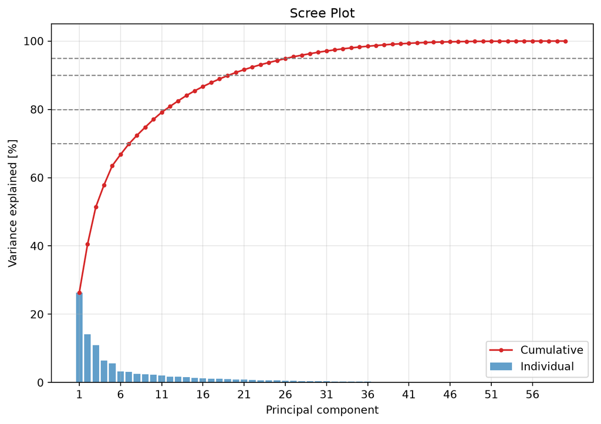

A plot of this shape is called a **scree plot**, after the slope of loose rubble at the foot of a cliff. The first few principal components explain a large fraction of the variance, while later components contribute progressively less.

Here, the first **three components explain 51.4%** of the variance in a dataset containing **60 variables**. Retaining only **8 components** preserves more than **70%** of the variance, while **20 components** preserve **90%**. This suggests that many of the original variables contain overlapping information and that the dimensionality of the dataset can be substantially reduced.

The scree plot exhibits an elbow between approximately **5 and 10 components**, after which the gains in explained variance become much smaller. In Part D, we will use a more systematic approach to determine how many components should be retained.

**NoteThe tail of the scree plot is the database repeating itself**

The scree plot shows that several principal components explain very little variance. This suggests that some of the original variables contain overlapping information.

In general, components associated with very small eigenvalues often correspond to combinations of variables that carry little new information. This is one reason why PCA can reduce the dimensionality of a dataset while retaining most of its important patterns.

**Callout-answer**Answer**

```
plot_explained_variance.py
```

```python
def plot_explained_variance(variance, targets=(70, 80, 90, 95)):
    """
    Print and plot the variance explained by each principal component.

    Parameters
    ----------
    variance : np.ndarray
        The variance carried by each component, from fit_pca.
    targets : tuple of int, optional
        Percentages to report a component count for.

    Returns
    -------
    ratios, cumulative : np.ndarray
        The individual and cumulative percentage of variance explained.
    """
    ratios = 100 * variance / variance.sum()
    cumulative = np.cumsum(ratios)
    components = np.arange(1, len(ratios) + 1)

    for k in range(10):
        print(f"PC{k + 1:<3d} explains {ratios[k]:5.1f}%    cumulative {cumulative[k]:5.1f}%")

    print()
    for target in targets:
        print(f"{target}% of the variance needs {components[cumulative >= target][0]:2d} of {len(ratios)} components")

    plt.figure(figsize=(9, 6))
    plt.bar(components, ratios, alpha=0.7, label="Individual")
    plt.plot(components, cumulative, "o-", markersize=3, color="C3", label="Cumulative")
    for target in targets:
        needed = components[cumulative >= target][0]
        plt.axhline(target, color="grey", linestyle="--", linewidth=1)
    plt.xticks(components[::5])
    plt.xlabel("Principal component")
    plt.ylabel("Variance explained [%]")
    plt.title("Scree Plot")
    plt.legend()
    plt.grid(True, alpha=0.3)
    plt.show()
    return ratios, cumulative

ratios, cumulative = plot_explained_variance(variance)
```

Output

```
PC1   explains  26.4%    cumulative  26.4%
PC2   explains  14.1%    cumulative  40.5%
PC3   explains  10.9%    cumulative  51.4%
PC4   explains   6.5%    cumulative  57.9%
PC5   explains   5.6%    cumulative  63.5%
PC6   explains   3.3%    cumulative  66.8%
PC7   explains   3.1%    cumulative  69.8%
PC8   explains   2.6%    cumulative  72.4%
PC9   explains   2.4%    cumulative  74.8%
PC10  explains   2.3%    cumulative  77.1%

70% of the variance needs  8 of 60 components
80% of the variance needs 12 of 60 components
90% of the variance needs 20 of 60 components
95% of the variance needs 27 of 60 components
```

Output

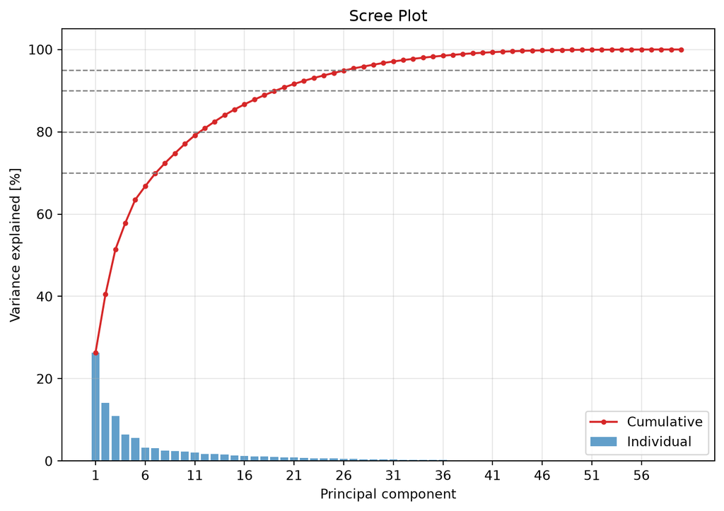

## Part C: Reading the components

So far, we have reduced a dataset containing 60 nutritional variables to a much smaller set of principal components while retaining most of the variation in the data. The next step is to understand what these components represent and how they help us interpret the foods.

In this part, we will explore the **scores**, which tell us where foods lie in the new component space, and the **loadings**, which tell us which nutrients are responsible for the patterns we observe. Together, these allow us to identify similarities between foods and understand the nutritional characteristics captured by each component.

### Task 7 : Plot the foods in component space

Write a function `plot_scores` that creates a scatter plot of the first two principal component scores and colours each point according to its food group. Plot the `"Other"` group first in light grey so that it appears behind the remaining food groups and does not obscure them.

**TipSelecting rows of a NumPy array with a pandas mask**

`groups == "Fruit"` returns a boolean pandas Series, while `scores` is a NumPy array. Use `.to_numpy()` to convert the Series into a NumPy boolean array before indexing:

```python
scores[(groups == "Fruit").to_numpy(), 0]
```

`markerscale` in `plt.legend` enlarges the legend markers without touching the plotted points, which is worth setting when the points are small.

```
plot_scores.py
```

```python
def plot_scores(scores, groups, title="Foods in Principal Component Space"):
    """
    Scatter the first two principal components, coloured by food group.

    Parameters
    ----------
    scores : np.ndarray
        The component scores, one row per food.
    groups : pd.Series
        The food group label of each food, used only for colour.
    title : str, optional
        The plot title.
    """
```

When you run this function, it should yield the following output:

plot_scores(scores, groups)

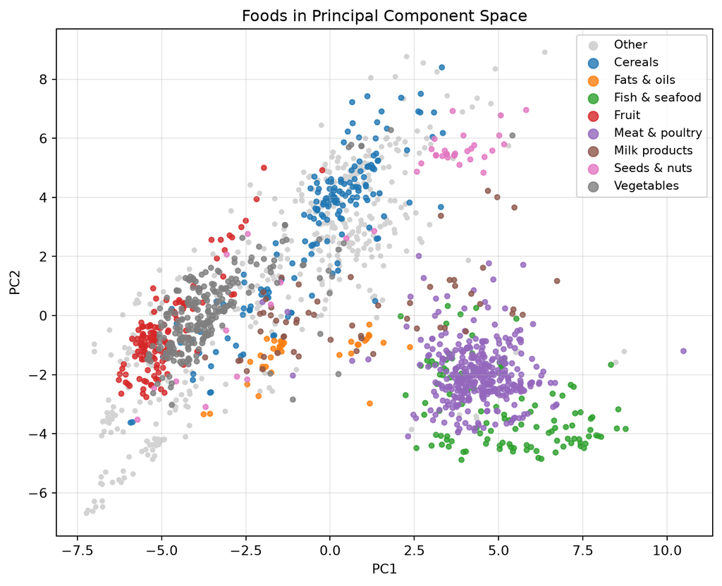

The food groups occupy distinct regions of a plot that was constructed without using any of the food-group labels. Fruits cluster on the left, cereals appear mainly in the upper region, seeds and nuts occupy the upper right, while meat, poultry, and seafood are concentrated on the right-hand side. Vegetables lie between these groups, reflecting their wide range of nutritional compositions.

The fact that these categories separate naturally suggests that the first two principal components capture meaningful nutritional differences between foods. Fats and oils, however, cluster closer to the centre of the plot, indicating that the characteristics that distinguish them are likely captured by later principal components rather than by PC1 and PC2 alone.

This raises the next question: **what nutritional properties are PC1 and PC2 actually measuring?**

**Callout-answer**Answer**

```
plot_scores.py
```

```python
def plot_scores(scores, groups, title="Foods in Principal Component Space"):
    """
    Scatter the first two principal components, coloured by food group.

    Parameters
    ----------
    scores : np.ndarray
        The component scores, one row per food.
    groups : pd.Series
        The food group label of each food, used only for colour.
    title : str, optional
        The plot title.
    """
    plt.figure(figsize=(9, 7))

    # Draw the unlabelled foods first so the coloured groups sit on top
    other = (groups == "Other").to_numpy()
    plt.scatter(scores[other, 0], scores[other, 1], s=10, color="lightgrey", label="Other")

    for group in sorted(set(groups) - {"Other"}):
        mask = (groups == group).to_numpy()
        plt.scatter(scores[mask, 0], scores[mask, 1], s=14, alpha=0.8, label=group)

    plt.xlabel("PC1")
    plt.ylabel("PC2")
    plt.title(title)
    plt.legend(markerscale=2, fontsize=9)
    plt.grid(True, alpha=0.3)
    plt.show()

plot_scores(scores, groups)
```

Output

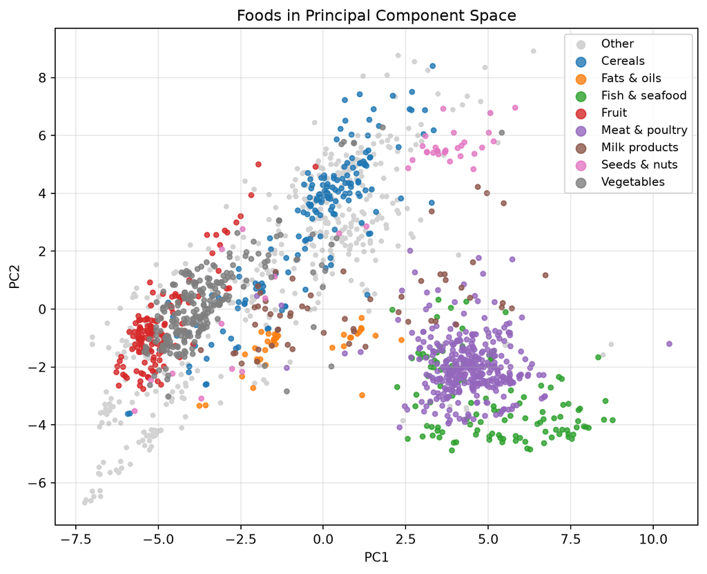

### Task 8 : Read the loadings

To answer that, we need to examine the **loadings**. The loadings show how strongly each nutrient contributes to a principal component, and therefore help us interpret what each axis represents. By identifying the analytes with the largest positive and negative loadings, we can determine which nutritional characteristics are responsible for the patterns observed in the score plot.

Write a function `plot_loadings` that, for each of the first few components, picks the features with the largest loadings by magnitude and draws them as a horizontal bar chart.

**TipPicking the largest loadings and drawing them sideways**

`column.abs().sort_values(ascending=False).index[:n]` gives the names of the `n` features with the biggest loadings, whichever way they point, and indexing the original Series with those names recovers the signed values. Draw them with `Series.plot.barh`, since horizontal bars leave room for long analyte names that would overlap on an x-axis. `plt.subplots(n_components, 1)` stacks one panel per component. See [Series.plot.barh](https://pandas.pydata.org/docs/reference/api/pandas.Series.plot.barh.html).

```
plot_loadings.py
```

```python
def plot_loadings(loadings, feature_names, n_components=3, n_features=10):
    """
    Draw the largest loadings of each leading component as horizontal bars.

    Parameters
    ----------
    loadings : np.ndarray
        The loading matrix from fit_pca.
    feature_names : sequence of str
        The names of the original features, in column order.
    n_components : int, optional
        How many components to show (default is 3).
    n_features : int, optional
        How many features to show per component (default is 10).
    """
```

When you run this function, it should yield the following output:

plot_loadings(loadings, X.columns, n_components=3)

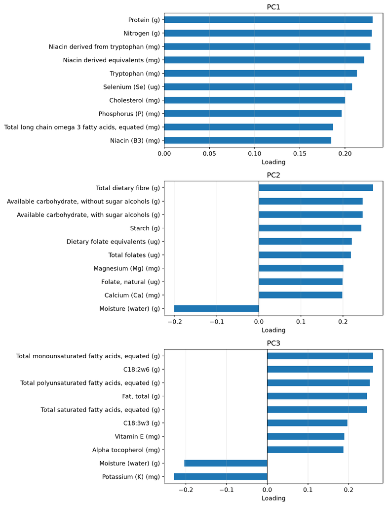

Each principal component is a combination of all sixty nutrients, and the loadings tell us which nutrients contribute most strongly to it. By looking at the nutrients with the largest loadings, we can work out what each component represents.

| Component | Large and positive | Large and negative | Interpretation |
| --- | --- | --- | --- |
| **PC1** (26.4%) | Protein, nitrogen, tryptophan, niacin, selenium, cholesterol, phosphorus | No major negative loadings | Animal protein content |
| **PC2** (14.1%) | Fibre, available carbohydrate, starch, folates, magnesium, calcium | Moisture | Dry, starchy foods vs water-rich foods |
| **PC3** (10.9%) | Fat and all four fatty acid groups, vitamin E | Moisture, potassium | Fat content |

Now return to the score plot. Foods rich in animal protein, such as meat, poultry, and seafood, appear on the right because they score highly on **PC1**. Cereals, seeds, and nuts appear toward the top because they are rich in starch and fibre, giving them high **PC2** scores. Fruits and vegetables tend to lie toward the lower left because they contain large amounts of water and relatively low concentrations of many other nutrients.

Fats and oils do not separate strongly on the PC1-PC2 plot because the property that distinguishes them most is their high fat content, which is captured mainly by **PC3** rather than the first two components.

**Callout-answer**Answer**

```
plot_loadings.py
```

```python
def plot_loadings(loadings, feature_names, n_components=3, n_features=10):
    """
    Draw the largest loadings of each leading component as horizontal bars.

    Parameters
    ----------
    loadings : np.ndarray
        The loading matrix from fit_pca.
    feature_names : sequence of str
        The names of the original features, in column order.
    n_components : int, optional
        How many components to show (default is 3).
    n_features : int, optional
        How many features to show per component (default is 10).
    """
    fig, axes = plt.subplots(n_components, 1, figsize=(9, 4 * n_components))

    for i, ax in enumerate(axes):
        column = pd.Series(loadings[:, i], index=feature_names)
        top = column[column.abs().sort_values(ascending=False).index[:n_features]]

        top.sort_values().plot.barh(ax=ax)
        ax.axvline(0, color="black", linewidth=0.8)
        ax.set_title(f"PC{i + 1}")
        ax.set_xlabel("Loading")
        ax.grid(True, alpha=0.3, axis="x")

    plt.tight_layout()
    plt.show()

plot_loadings(loadings, X.columns, n_components=3)
```

Output

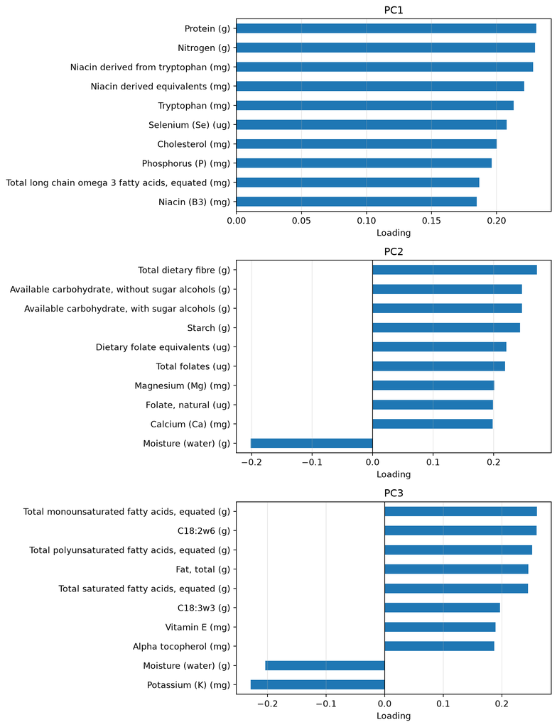

### Task 9 : Put the samples and the variables on one plot

Flipping between a score plot and a loading plot to interpret a sample is tedious. A **biplot** draws both at once: the samples as points, and each original variable as an arrow pointing in the direction that variable increases. Sixty arrows would be a thicket, so draw only the longest ones, which are the analytes best represented in this plane.

Write a function `plot_biplot` that does this for the first two components. The loadings are all smaller than one, so the arrows would be invisible next to scores that run from −7 to +10. Multiply them by a scale factor chosen to make the arrows span roughly the same range as the points. That factor is cosmetic and changes nothing about the analysis.

**TipArrow length, and keeping the labels apart**

The arrow for feature `i` runs from the origin to `(loadings[i, 0], loadings[i, 1])`, so its length in this plane is `np.hypot(loadings[:, 0], loadings[:, 1])`, and sorting that array picks out the analytes worth drawing. Nearly parallel arrows will print their labels on top of each other, so push each label out to a slightly different distance along its own arrow: multiplying the tip coordinates by something like `1.06 + 0.16 * (rank % 3)` cycles through three radii and keeps them legible.

```
plot_biplot.py
```

```python
def plot_biplot(scores, loadings, feature_names, n_arrows=8, arrow_scale=25):
    """
    Draw the samples and the best-represented variable directions on one pair of axes.

    Parameters
    ----------
    scores : np.ndarray
        The component scores, one row per sample.
    loadings : np.ndarray
        The loading matrix from fit_pca.
    feature_names : sequence of str
        The names of the original features, in column order.
    n_arrows : int, optional
        How many of the longest arrows to draw (default is 8).
    arrow_scale : float, optional
        Cosmetic factor that lengthens the loading arrows to match the score range.
    """
```

plot_biplot(scores, loadings, X.columns)

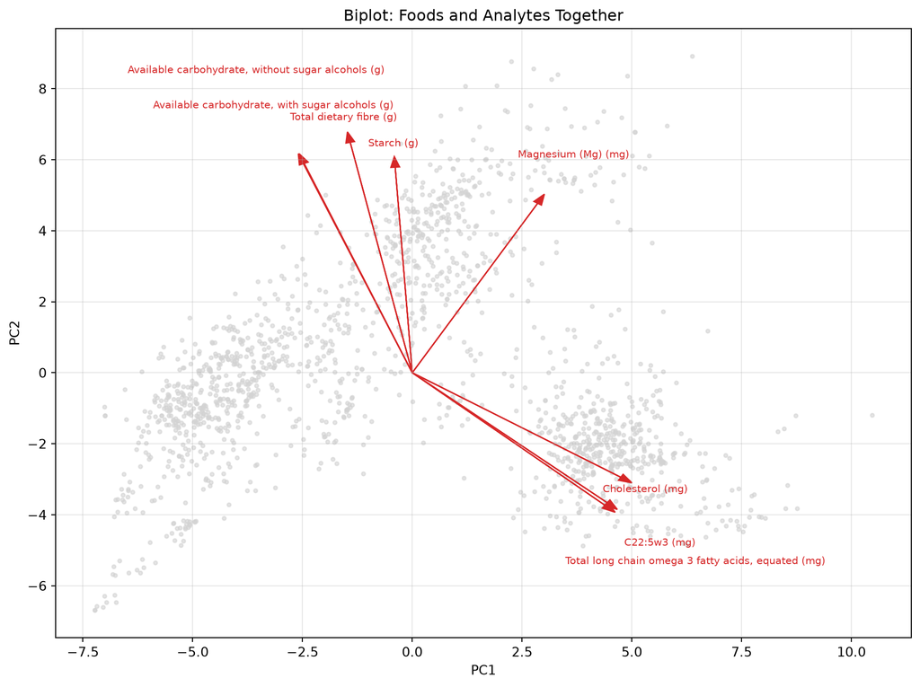

Three things are readable from a biplot that are not obvious from either plot alone. Arrows pointing the same way are correlated variables, which is why the two available-carbohydrate columns, starch and fibre lie almost on top of one another, and why long-chain omega 3 and C22:5w3 do the same in the opposite quadrant. Arrows pointing in opposite directions are inversely related. And a sample lying far out along an arrow is high in that variable, so the foods spread up and to the left towards the fibre and starch arrows are the cereals, and those down and to the right along the cholesterol arrow are the fish and the meat.

An arrow that stays short, as most of the other fifty-two do, means the variable is poorly represented in this plane. Vitamin C, as an example, would barely register on either of these axes.

**Callout-answer**Answer**

```
plot_biplot.py
```

```python
def plot_biplot(scores, loadings, feature_names, n_arrows=8, arrow_scale=25):
    """
    Draw the samples and the best-represented variable directions on one pair of axes.

    Parameters
    ----------
    scores : np.ndarray
        The component scores, one row per sample.
    loadings : np.ndarray
        The loading matrix from fit_pca.
    feature_names : sequence of str
        The names of the original features, in column order.
    n_arrows : int, optional
        How many of the longest arrows to draw (default is 8).
    arrow_scale : float, optional
        Cosmetic factor that lengthens the loading arrows to match the score range.
    """
    plt.figure(figsize=(10, 7.5))
    plt.scatter(scores[:, 0], scores[:, 1], s=8, color="lightgrey", alpha=0.6)

    length = np.hypot(loadings[:, 0], loadings[:, 1])
    longest = np.argsort(length)[::-1][:n_arrows]

    for rank, i in enumerate(longest):
        dx, dy = arrow_scale * loadings[i, 0], arrow_scale * loadings[i, 1]
        plt.arrow(0, 0, dx, dy, color="C3", head_width=0.2, length_includes_head=True)

        # Stagger the labels so nearly parallel arrows do not print on top of each other
        offset = 1.06 + 0.16 * (rank % 3)
        plt.text(offset * dx, offset * dy, feature_names[i],
                 color="C3", ha="center", va="center", fontsize=8)

    plt.xlabel("PC1")
    plt.ylabel("PC2")
    plt.title("Biplot: Foods and Analytes Together")
    plt.grid(True, alpha=0.3)
    plt.tight_layout()
    plt.show()

plot_biplot(scores, loadings, X.columns)
```

Output

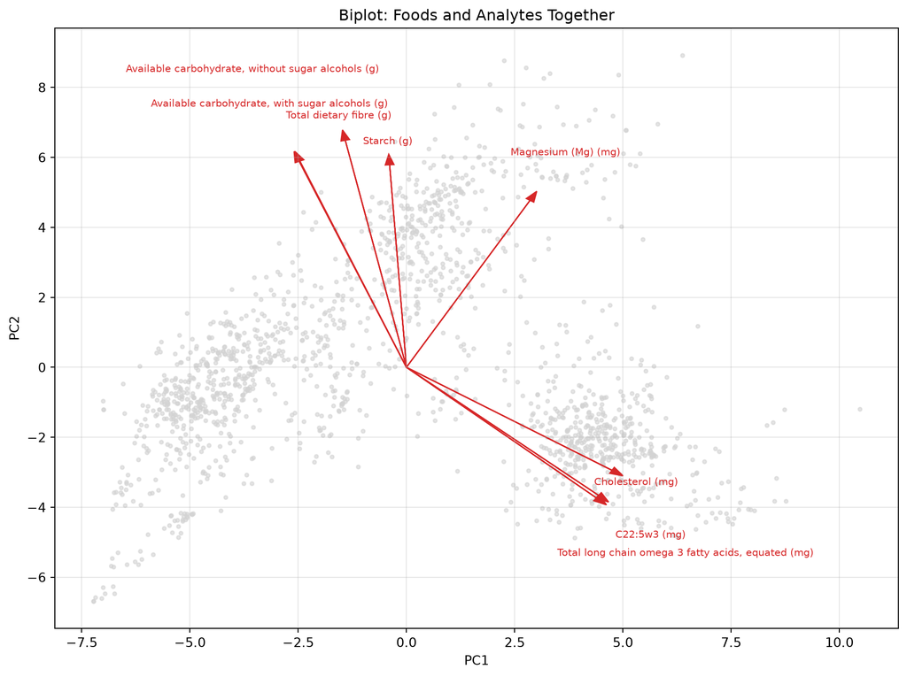

## Part D: Choosing How Many Components to Keep

The scree plot said twenty components for 90%, but that reading came from the same 1588 foods the components were fitted to. Lets see how well the components generalise to new foods, and whether twenty is really the right number.

### Task 10 : Split into training and testing sets

Use an **80/20 train-test split** with a `test_size` of `0.2` and a `random_state` of `42`. Split the food names alongside the features so that the two stay aligned.

X_train, X_test, names_train, names_test = train_test_split(

X, names, test_size=0.2, random_state=42)

X_train.shape, X_test.shape

((1270, 60), (318, 60))

**Callout-answer**Answer**

```
split_food_data.py
```

```python
X_train, X_test, names_train, names_test = train_test_split(
    X, names, test_size=0.2, random_state=42)

print(X_train.shape, X_test.shape)
```

Output

```
(1270, 60) (318, 60)
```

### Task 11 : Rebuild the table from a few components

Compression is only worth anything if the original numbers can be recovered from it. Write a function `reconstruct` that projects a table onto the components, keeps the first `n_components` columns of the scores, and multiplies back to return a table with all sixty columns.

Use it to rebuild one food from 1, 5, 10, 20 and 40 components. The function works on the log scale it was given, so apply `np.expm1` to undo the log and read the answer in grams and milligrams.

**TipGoing backwards**

Because the loading matrix is orthogonal, running the projection backwards is a matter of multiplying by its transpose. Keeping only $k$ components means keeping the first $k$ columns of both the scores and the loadings:

$$\hat{\mathbf{Z}} = \mathbf{T}_{[:,\,1:k]}\,\mathbf{V}_{[:,\,1:k]}^{\top}$$

which in NumPy is `scores[:, :k] @ loadings[:, :k].T`, where `.T` is the transpose. That gives the reconstruction on the standardised scale, so `scaler.inverse_transform` returns it to the log scale. Wrapping the result in a DataFrame keeps the column names.

```
reconstruct.py
```

```python
def reconstruct(X, scaler, loadings, n_components):
    """
    Compress a table to n_components and rebuild all of its columns.

    Parameters
    ----------
    X : pd.DataFrame
        The feature table.
    scaler : StandardScaler
        The fitted scaler from fit_pca.
    loadings : np.ndarray
        The loading matrix from fit_pca.
    n_components : int
        How many components to keep before rebuilding.

    Returns
    -------
    X_hat : pd.DataFrame
        The reconstructed table, with the same shape and columns as X.
    """
```

SHOW = {"Energy with dietary fibre, equated (kJ)": "Energy [kJ]",

"Moisture (water) (g)": "Moisture [g]",

"Protein (g)": "Protein [g]",

"Fat, total (g)": "Fat [g]",

"Available carbohydrate, without sugar alcohols (g)": "Carb [g]",

"Total dietary fibre (g)": "Fibre [g]",

"Calcium (Ca) (mg)": "Calcium [mg]",

"Vitamin C (mg)": "Vitamin C [mg]"}

row = names[names == "Broccoli, fresh, raw"].index[0]

rebuilt = pd.DataFrame({"Measured": np.expm1(X.loc[row])})

for k in [1, 5, 10, 20, 40]:

rebuilt[f"{k} PCs"] = np.expm1(reconstruct(X, scaler, loadings, k).loc[row])

rebuilt = rebuilt.loc[list(SHOW)].rename(index=SHOW)

print("Broccoli, fresh, raw")

Broccoli, fresh, raw

rebuilt.round(1)

Measured 1 PCs 5 PCs 10 PCs 20 PCs 40 PCs

Energy [kJ] 134.0 313.5 121.0 125.7 112.3 134.9

Moisture [g] 89.9 44.8 114.3 120.4 115.1 90.0

Protein [g] 4.0 2.0 2.6 2.5 2.4 3.5

Fat [g] 0.4 1.2 0.2 0.2 0.4 0.3

Carb [g] 1.2 9.5 2.8 2.7 1.9 1.2

Fibre [g] 3.5 1.8 3.9 3.6 3.2 3.5

Calcium [mg] 36.0 17.1 37.9 29.4 33.5 36.1

Vitamin C [mg] 88.0 2.9 20.1 22.2 28.0 87.8

With a single component the reconstruction is a generic food. It gives broccoli 313 kJ against a measured 134, 45 g of water against 90, and 2.9 mg of vitamin C against 88, because along one axis the only thing PCA knows about broccoli is that it is not animal tissue, and the average food that is not animal tissue looks nothing like a green vegetable. Five components fix the energy and the fibre, and put the moisture at 114 g in 100 g of food, which is a reminder that a reconstruction is a projection and is under no obligation to be physically possible.

Vitamin C is the interesting one. It climbs slowly, 20 mg at five components and 28 mg at twenty, and only reaches the measured 88 mg once forty components are in play. Vitamin C is close to uncorrelated with everything else in the table, so no early component carries it, and the model concedes that broccoli is a vitamin C source only when there is nothing else left to explain.

**Callout-answer**Answer**

```
reconstruct.py
```

```python
def reconstruct(X, scaler, loadings, n_components):
    """
    Compress a table to n_components and rebuild all of its columns.

    Parameters
    ----------
    X : pd.DataFrame
        The feature table.
    scaler : StandardScaler
        The fitted scaler from fit_pca.
    loadings : np.ndarray
        The loading matrix from fit_pca.
    n_components : int
        How many components to keep before rebuilding.

    Returns
    -------
    X_hat : pd.DataFrame
        The reconstructed table, with the same shape and columns as X.
    """
    scores = pca_scores(X, scaler, loadings)
    Z_hat = scores[:, :n_components] @ loadings[:, :n_components].T
    return pd.DataFrame(scaler.inverse_transform(Z_hat), columns=X.columns, index=X.index)

# Eight of the sixty columns, with short names, so that the table fits on the page
SHOW = {"Energy with dietary fibre, equated (kJ)": "Energy [kJ]",
        "Moisture (water) (g)": "Moisture [g]",
        "Protein (g)": "Protein [g]",
        "Fat, total (g)": "Fat [g]",
        "Available carbohydrate, without sugar alcohols (g)": "Carb [g]",
        "Total dietary fibre (g)": "Fibre [g]",
        "Calcium (Ca) (mg)": "Calcium [mg]",
        "Vitamin C (mg)": "Vitamin C [mg]"}

row = names[names == "Broccoli, fresh, raw"].index[0]

rebuilt = pd.DataFrame({"Measured": np.expm1(X.loc[row])})
for k in [1, 5, 10, 20, 40]:
    rebuilt[f"{k} PCs"] = np.expm1(reconstruct(X, scaler, loadings, k).loc[row])

rebuilt = rebuilt.loc[list(SHOW)].rename(index=SHOW)
print("Broccoli, fresh, raw")
print(rebuilt.round(1))
```

Output

```
Broccoli, fresh, raw
                Measured  1 PCs  5 PCs  10 PCs  20 PCs  40 PCs
Energy [kJ]        134.0  313.5  121.0   125.7   112.3   134.9
Moisture [g]        89.9   44.8  114.3   120.4   115.1    90.0
Protein [g]          4.0    2.0    2.6     2.5     2.4     3.5
Fat [g]              0.4    1.2    0.2     0.2     0.4     0.3
Carb [g]             1.2    9.5    2.8     2.7     1.9     1.2
Fibre [g]            3.5    1.8    3.9     3.6     3.2     3.5
Calcium [mg]        36.0   17.1   37.9    29.4    33.5    36.1
Vitamin C [mg]      88.0    2.9   20.1    22.2    28.0    87.8
```

### Task 12 : Score the rebuild on data the model has not seen

Write a function `variance_explained` that measures how much of the variation in *any* table a $k$-component model reproduces, as

$$\text{variance explained} = 1 - \frac{\sum(\mathbf{Z} - \hat{\mathbf{Z}})^2}{\sum \mathbf{Z}^2}$$

where $\mathbf{Z}$ is the standardised table and $\hat{\mathbf{Z}}$ is its reconstruction. Then fit the components on the training set only and compare the training and testing sets over a range of $k$.

Work on the **standardised** scale. The sixty columns are a mix of kJ, g, mg and µg, and adding an error in kJ to an error in µg would produce a number dominated entirely by whichever column has the largest units, which is the same trap as skipping the scaling.

**TipReusing what you have already written**

`reconstruct` returns the rebuild on the log scale, so pass it back through `scaler.transform` before comparing. `((Z - Z_hat) ** 2).sum()` adds the squared error over every element of the array, and `(Z ** 2).sum()` is the total variation available, so the ratio is the fraction left unexplained.

```
variance_explained.py
```

```python
def variance_explained(X, scaler, loadings, n_components):
    """
    Fraction of the standardised variation in X that n_components reproduce.

    Parameters
    ----------
    X : pd.DataFrame
        The feature table to score.
    scaler : StandardScaler
        The fitted scaler from fit_pca.
    loadings : np.ndarray
        The loading matrix from fit_pca.
    n_components : int
        How many components the model keeps.

    Returns
    -------
    float
        The fraction of variation reproduced, between 0 and 1.
    """
```

train_scaler, train_loadings, train_variance = fit_pca(X_train)

for k in [1, 3, 5, 10, 15, 20, 25, 30, 40, 50]:

train = variance_explained(X_train, train_scaler, train_loadings, k)

test = variance_explained(X_test, train_scaler, train_loadings, k)

print(f"k = {k:2d} training {100 * train:5.1f}% testing {100 * test:5.1f}%")

k = 1 training 26.6% testing 23.7%

k = 3 training 51.4% testing 48.7%

k = 5 training 63.5% testing 60.8%

k = 10 training 77.1% testing 74.5%

k = 15 training 85.4% testing 84.1%

k = 20 training 90.8% testing 90.1%

k = 25 training 94.3% testing 93.9%

k = 30 training 96.7% testing 96.7%

k = 40 training 99.2% testing 99.1%

k = 50 training 99.9% testing 99.9%

**Callout-answer**Answer**

```
variance_explained.py
```

```python
def variance_explained(X, scaler, loadings, n_components):
    """
    Fraction of the standardised variation in X that n_components reproduce.

    Parameters
    ----------
    X : pd.DataFrame
        The feature table to score.
    scaler : StandardScaler
        The fitted scaler from fit_pca.
    loadings : np.ndarray
        The loading matrix from fit_pca.
    n_components : int
        How many components the model keeps.

    Returns
    -------
    float
        The fraction of variation reproduced, between 0 and 1.
    """
    Z = scaler.transform(X)
    Z_hat = scaler.transform(reconstruct(X, scaler, loadings, n_components))
    return 1 - ((Z - Z_hat) ** 2).sum() / (Z ** 2).sum()

train_scaler, train_loadings, train_variance = fit_pca(X_train)

for k in [1, 3, 5, 10, 15, 20, 25, 30, 40, 50]:
    train = variance_explained(X_train, train_scaler, train_loadings, k)
    test = variance_explained(X_test, train_scaler, train_loadings, k)
    print(f"k = {k:2d}   training {100 * train:5.1f}%   testing {100 * test:5.1f}%")
```

Output

```
k =  1   training  26.6%   testing  23.7%
k =  3   training  51.4%   testing  48.7%
k =  5   training  63.5%   testing  60.8%
k = 10   training  77.1%   testing  74.5%
k = 15   training  85.4%   testing  84.1%
k = 20   training  90.8%   testing  90.1%
k = 25   training  94.3%   testing  93.9%
k = 30   training  96.7%   testing  96.7%
k = 40   training  99.2%   testing  99.1%
k = 50   training  99.9%   testing  99.9%
```

### Task 13 : Choose the number of components by cross-validation

The testing set has now been looked at, so it can no longer be used to choose anything. Do the choosing on the training set with **5-fold cross-validation**.

Write a function `cross_validate_components` that, for each fold, fits the components on four fifths of the training data and measures the variance explained on the fifth that was held out, for every value of $k$. Average across the folds, plot the result with error bars, and report the smallest $k$ that clears a target of 90%.

**TipSplitting without labels**

Use `KFold(n_splits=5, shuffle=True, random_state=42)` Its `.split(X_train)` method yields pairs of index arrays, one for the part of the training set to fit on and one for the part to score against, so `X_train.iloc[fit_index]` and `X_train.iloc[val_index]` give the two subsets.

Collect the results as a list of lists and convert with `np.array` to get a fold-by-$k$ grid. `curves.mean(axis=0)` then averages down the folds, and `curves.std(axis=0)` gives the spread for the error bars. Sixty printed lines is too many to read, so print every fifth. See [KFold](https://scikit-learn.org/stable/modules/generated/sklearn.model_selection.KFold.html) and [plt.errorbar](https://matplotlib.org/stable/api/_as_gen/matplotlib.pyplot.errorbar.html).

```
cross_validate_components.py
```

```python
def cross_validate_components(X_train, target=0.90, n_splits=5):
    """
    Cross-validate the number of components against a variance-explained target.

    Parameters
    ----------
    X_train : pd.DataFrame
        The training features.
    target : float, optional
        The fraction of variance the model must reproduce (default is 0.90).
    n_splits : int, optional
        The number of cross-validation folds (default is 5).

    Returns
    -------
    best : int
        The smallest number of components reaching the target.
    average : np.ndarray
        The mean held-out variance explained for each number of components.
    """
```

best_k, cv_curve = cross_validate_components(X_train, target=0.90)

k = 1 variance explained 26.2% ± 2.4%

k = 5 variance explained 62.5% ± 3.2%

k = 10 variance explained 75.5% ± 3.1%

k = 15 variance explained 84.3% ± 1.1%

k = 20 variance explained 89.9% ± 0.6%

k = 25 variance explained 93.5% ± 0.5%

k = 30 variance explained 96.2% ± 0.2%

k = 35 variance explained 98.0% ± 0.1%

k = 40 variance explained 99.1% ± 0.0%

k = 45 variance explained 99.7% ± 0.0%

k = 50 variance explained 99.9% ± 0.0%

k = 55 variance explained 100.0% ± 0.0%

k = 60 variance explained 100.0% ± 0.0%

Smallest number of components reaching 90%: 21

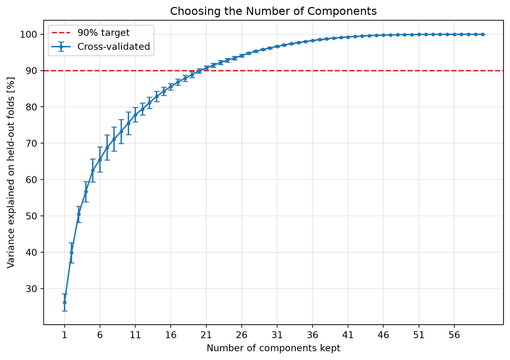

Cross-validation puts the answer at 21 components out of 60. The scree plot, fitted to everything, said 20. One component of optimism across a sixty-column table is a small correction, and the error bars explain why: fold-to-fold spread peaks at 3.4 percentage points around $k = 7$ and falls below one point by the time the curve reaches the target. With 1270 training foods and 60 columns there is very little room to overfit a covariance matrix, so the in-sample estimate was close to honest to begin with.

The result is worth stating plainly. Two thirds of a sixty-column analytical table can be discarded for a tenth of its information, and that holds up on foods the model was never fitted to.

**NoteWhy cross-validate an unsupervised model at all**

PCA has no target, so there is nothing to be right or wrong about in the usual sense, and it is common to see it fitted to a whole dataset with the number of components read straight off a scree plot. That works when the components are only ever going to be looked at.

It stops working as soon as the components are used for something. A reduced model becomes part of a pipeline: the scores feed a regression, or the reconstruction error raises an alarm. At that point the number of components is a hyperparameter like any other, chosen to make the model work on data it has not seen, and choosing it from in-sample variance overstates how well the compression will hold up. Reconstructing held-out samples gives you a genuine out-of-sample quantity to select on without ever needing a label.

The correction was small here. Run the same procedure on a table with 200 tags and 300 samples and it will not be, which is exactly the case where you would most want to trust the answer.

**Callout-answer**Answer**

```
cross_validate_components.py
```

```python
def cross_validate_components(X_train, target=0.90, n_splits=5):
    """
    Cross-validate the number of components against a variance-explained target.

    Parameters
    ----------
    X_train : pd.DataFrame
        The training features.
    target : float, optional
        The fraction of variance the model must reproduce (default is 0.90).
    n_splits : int, optional
        The number of cross-validation folds (default is 5).

    Returns
    -------
    best : int
        The smallest number of components reaching the target.
    average : np.ndarray
        The mean held-out variance explained for each number of components.
    """
    folds = KFold(n_splits=n_splits, shuffle=True, random_state=42)
    components = np.arange(1, X_train.shape[1] + 1)

    curves = []
    for fit_index, val_index in folds.split(X_train):
        scaler, loadings, variance = fit_pca(X_train.iloc[fit_index])
        curves.append([variance_explained(X_train.iloc[val_index], scaler, loadings, k)
                       for k in components])

    curves = 100 * np.array(curves)
    average, spread = curves.mean(axis=0), curves.std(axis=0)

    for k, value, error in zip(components, average, spread):
        if k == 1 or k % 5 == 0:
            print(f"k = {k:2d}   variance explained {value:5.1f}%  ± {error:.1f}%")

    best = int(components[average >= 100 * target][0])
    print(f"\nSmallest number of components reaching {100 * target:.0f}%: {best}")

    plt.figure(figsize=(9, 6))
    plt.errorbar(components, average, yerr=spread, fmt="o-", markersize=3,
                 capsize=3, label="Cross-validated")
    plt.axhline(100 * target, color="C3", linestyle="--", label=f"{100 * target:.0f}% target")
    plt.xticks(components[::5])
    plt.xlabel("Number of components kept")
    plt.ylabel("Variance explained on held-out folds [%]")
    plt.title("Choosing the Number of Components")
    plt.legend()
    plt.grid(True, alpha=0.3)
    plt.show()
    return best, average

best_k, cv_curve = cross_validate_components(X_train, target=0.90)
```

Output

```
k =  1   variance explained  26.2%  ± 2.4%
k =  5   variance explained  62.5%  ± 3.2%
k = 10   variance explained  75.5%  ± 3.1%
k = 15   variance explained  84.3%  ± 1.1%
k = 20   variance explained  89.9%  ± 0.6%
k = 25   variance explained  93.5%  ± 0.5%
k = 30   variance explained  96.2%  ± 0.2%
k = 35   variance explained  98.0%  ± 0.1%
k = 40   variance explained  99.1%  ± 0.0%
k = 45   variance explained  99.7%  ± 0.0%
k = 50   variance explained  99.9%  ± 0.0%
k = 55   variance explained 100.0%  ± 0.0%
k = 60   variance explained 100.0%  ± 0.0%

Smallest number of components reaching 90%: 21
```

Output

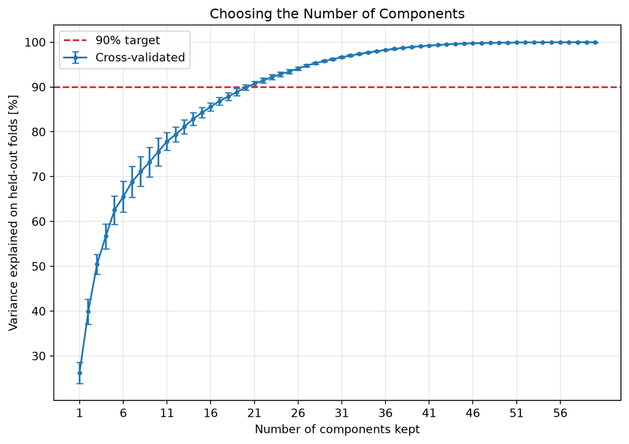

### Task 14 : Find the samples the model cannot explain

Everything so far has been averaged over foods. The reconstruction error is computed one food at a time, though, and a food with a large error is one that does not behave like the rest of the dataset.

Write a function `find_unusual_foods` that fits the components on the training set, squares the reconstruction error of each testing food separately, prints the worst offenders, and draws the distribution. Keep five components, so that the model is tight enough for the misfits to stand out.

**TipOne number per sample**

The difference from `variance_explained` is a single argument. `((Z - Z_hat) ** 2).sum()` collapses the whole array to one number, while `((Z - Z_hat) ** 2).sum(axis=1)` sums across the columns only and leaves one number per row. A histogram of the result is easier to read on a log y-axis, set with `plt.yscale("log")`, because most foods sit near the median.

```
find_unusual_foods.py
```

```python
def find_unusual_foods(X_train, X_test, names_test, n_components=5, n_show=10):
    """
    Rank testing samples by how badly a reduced PCA model rebuilds them.

    Parameters
    ----------
    X_train, X_test : pd.DataFrame
        The training and testing features.
    names_test : pd.Series
        The name of each testing sample.
    n_components : int, optional
        How many components the model keeps (default is 5).
    n_show : int, optional
        How many of the worst samples to print (default is 10).

    Returns
    -------
    ranked : pd.DataFrame
        Every testing sample with its squared reconstruction error, worst first.
    """
```

ranked = find_unusual_foods(X_train, X_test, names_test, n_components=5)

Median error across the testing foods: 15.7

The 10 testing foods the model explains worst:

543.4 Spread, yeast, vegemite

276.8 Coffee, instant, dry powder or granules

149.2 Oil, linseed or flaxseed

146.8 Vanilla bean extract

136.7 Coffee, espresso, from ground coffee beans

123.8 Soft drink, energy drink, V

117.2 Cocoa powder

87.3 Margarine spread, polyunsaturated (~70% fat), reduced salt

87.2 Chocolate, dark, no added sugar

79.0 Wine, fortified, sherry, sweet style (~11% sugars)

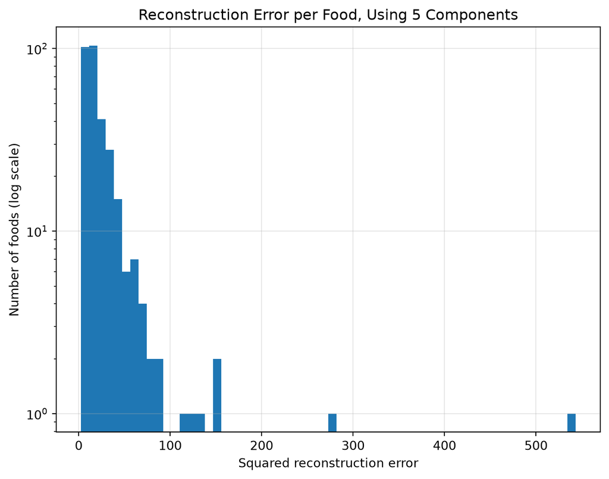

The median testing food has an error of about 16 and the distribution falls away smoothly, but a handful sit tens of times higher, and they have something in common. Vegemite carries 2454 µg of folate and 124 mg of niacin in 100 g, figures that no unfortified food comes close to. Instant coffee carries 3488 mg of caffeine, and caffeine is zero for 96% of the database. Vanilla extract is a third alcohol, and alcohol is zero for 98% of it. Linseed oil is 100 g of fat and nothing else at all.

Every one of these breaks the pattern the first five components encode, which is that a food is some mixture of animal tissue, dry plant matter and fat. None of them is a data error. They are genuinely unlike the 1270 foods the model was built from, and the model said so without being asked.

**NoteThis is how PCA monitors a process**

The quantity you just computed is used industrially, where it is called the **squared prediction error** or the **Q statistic**. The recipe is the same in a plant as it is here. Fit a PCA to historian data from a period when the unit was running normally, then for each new sample project it onto the model and reconstruct it. A small error means the new measurements sit in the same relationships to each other as they did during normal operation. A large error means those relationships have broken, and something has changed that the normal-operation model has no way to represent.

The strength of this over single-tag alarms is that every reading can be inside its own limits while the *combination* is impossible. A rise in reactor temperature is normal if the feed rate rose with it and abnormal if it did not, and a univariate alarm cannot tell those apart. The Q statistic can, which is why PCA sits underneath most multivariate statistical process control, and why fault detection tends to be the first thing an unsupervised method gets used for in a plant.

The train-test split you did earlier is the same split a plant makes between a normal-operation reference period and everything that comes after it.

**Callout-answer**Answer**

```
find_unusual_foods.py
```

```python
def find_unusual_foods(X_train, X_test, names_test, n_components=5, n_show=10):
    """
    Rank testing samples by how badly a reduced PCA model rebuilds them.

    Parameters
    ----------
    X_train, X_test : pd.DataFrame
        The training and testing features.
    names_test : pd.Series
        The name of each testing sample.
    n_components : int, optional
        How many components the model keeps (default is 5).
    n_show : int, optional
        How many of the worst samples to print (default is 10).

    Returns
    -------
    ranked : pd.DataFrame
        Every testing sample with its squared reconstruction error, worst first.
    """
    scaler, loadings, variance = fit_pca(X_train)

    Z = scaler.transform(X_test)
    Z_hat = scaler.transform(reconstruct(X_test, scaler, loadings, n_components))

    # Sum across the columns only, to get one number per food
    error = ((Z - Z_hat) ** 2).sum(axis=1)

    ranked = pd.DataFrame({"Food": names_test.to_numpy(), "Error": error})
    ranked = ranked.sort_values("Error", ascending=False)

    print(f"Median error across the testing foods: {np.median(error):.1f}\n")
    print(f"The {n_show} testing foods the model explains worst:")
    for _, food in ranked.head(n_show).iterrows():
        print(f"  {food['Error']:8.1f}   {food['Food'][:58]}")

    plt.figure(figsize=(8, 6))
    plt.hist(error, bins=60)
    plt.yscale("log")
    plt.xlabel("Squared reconstruction error")
    plt.ylabel("Number of foods (log scale)")
    plt.title(f"Reconstruction Error per Food, Using {n_components} Components")
    plt.grid(True, alpha=0.3)
    plt.show()
    return ranked

ranked = find_unusual_foods(X_train, X_test, names_test, n_components=5)
```

Output

```
Median error across the testing foods: 15.7

The 10 testing foods the model explains worst:
     543.4   Spread, yeast, vegemite
     276.8   Coffee, instant, dry powder or granules
     149.2   Oil, linseed or flaxseed
     146.8   Vanilla bean extract
     136.7   Coffee, espresso, from ground coffee beans
     123.8   Soft drink, energy drink, V
     117.2   Cocoa powder
      87.3   Margarine spread, polyunsaturated (~70% fat), reduced salt
      87.2   Chocolate, dark, no added sugar
      79.0   Wine, fortified, sherry, sweet style (~11% sugars)
```

Output

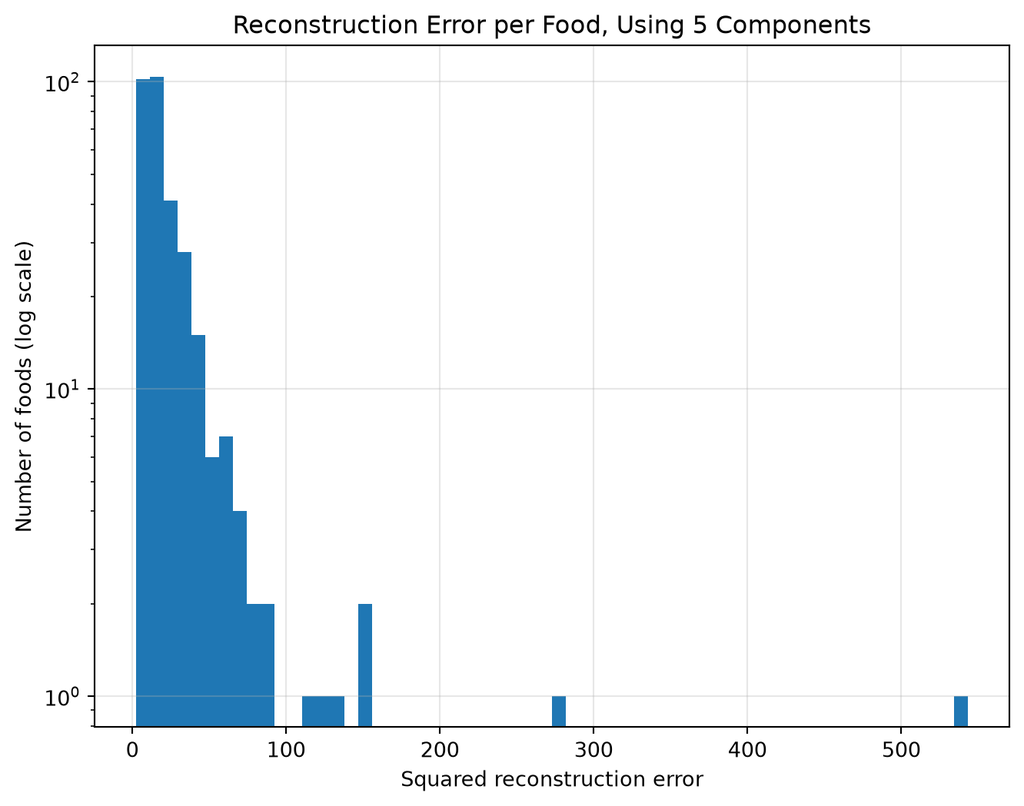

## Conclusion

This tutorial was the first without a target column, and the first in which you wrote the model itself instead of calling one. PCA was three steps of linear algebra: form the covariance matrix, take its eigenvectors, and sort them by eigenvalue. Everything after that, the scores, the loadings, the biplot, the reconstruction and the fault detector, was built on top of those three steps with matrix multiplication.

Everything measured for every food went in, and PCA worked out for itself that the table has far less in it than sixty independent numbers. Three components carry half the variation, and they turn out to mean animal tissue, dry plant matter and fat. Plotting foods against the first two reproduces the conventional food groups without ever being shown them, and cross-validation says that twenty-one components out of sixty reproduce 90% of the table on foods the model has never seen.

Finally, running the compression backwards turns a description into a detector. A sample that a reduced model cannot rebuild is a sample whose variables are not in their usual relationship to one another, which in a plant is the definition of a fault that no single-tag alarm will catch.

## Sources

- [NumPy linear algebra](https://numpy.org/doc/stable/reference/routines.linalg.html)
- [np.linalg.eigh](https://numpy.org/doc/stable/reference/generated/numpy.linalg.eigh.html)
- [StandardScaler](https://scikit-learn.org/stable/modules/generated/sklearn.preprocessing.StandardScaler.html)
- [Decomposing signals in components](https://scikit-learn.org/stable/modules/decomposition.html#pca)
- [KFold](https://scikit-learn.org/stable/modules/generated/sklearn.model_selection.KFold.html)
- [Importance of feature scaling](https://scikit-learn.org/stable/auto_examples/preprocessing/plot_scaling_importance.html)
- [Australian Food Composition Database](https://www.foodstandards.gov.au/science-data/food-composition-databases)